# Project1

In Figure 2, we can see the top five birth countries for nobel prize winners. To create this visual, we tallied the amount of winners born in each country and only portrayed the top five countries on the graph.

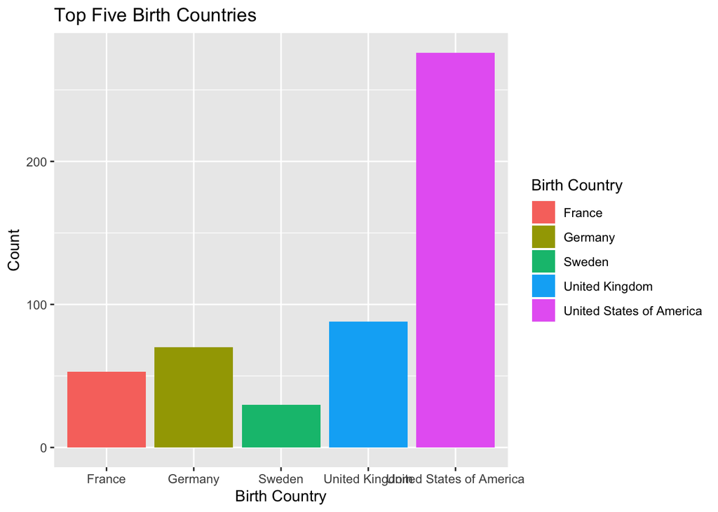

When analyzing the Nobel Prize Winner data, we can see that in general winners of the prizes get older over time. This is true in regards to both genders. To do this, we took the original data set to and categorized the year by every two decades. Then, the data was reduced to only the columns and rows needed for analysis. Next, we grouped the data by the time period and gender to ultimately create the dataset needed for our visuals. As shown in the graph: in the time period from 1900-1919, male winners are older; in 1920-1939, male winners are older; in the time period 1940-1959, female winners are older; in the time period 1960-1979, male winners are older; in the time period 1980-1999, female winners are older; in the time period 1960-1979, male winners are older; in the time period 2000-2020, male winners are older. Thus, in general, male winners are older than female winners. You can also see this in the dataset below showing the difference in average age of male and female recipients. This dataset was created by pivoting the initial data wider and making a new column showing the difference between average male and female age for winners at various time periods.

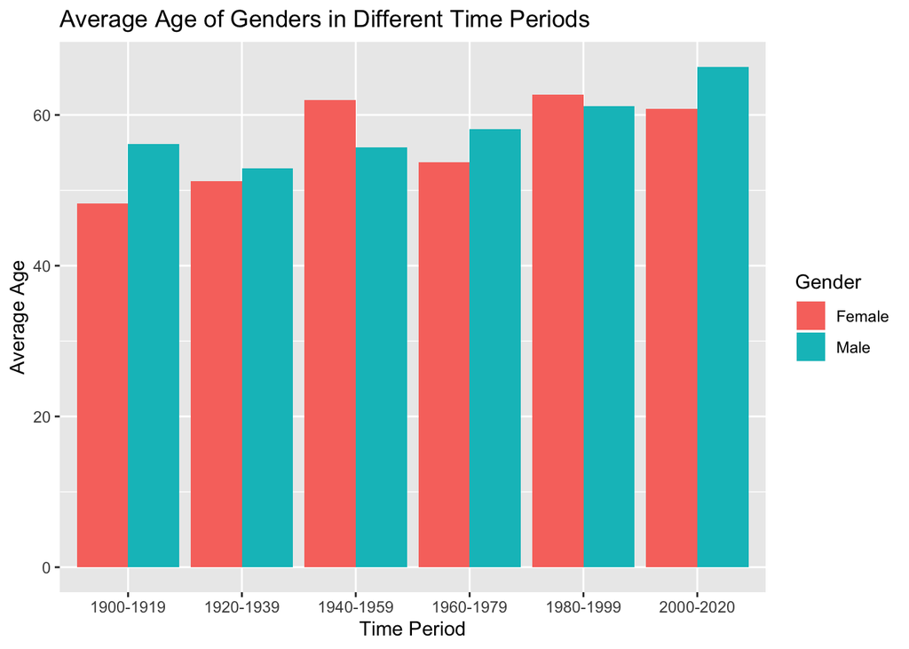

| Time Period | Female | Male | Average Age Difference |
| --- | --- | --- | --- |
| 1900-1919 | 48.25000 | 56.13187 | 7.881868 |
| 1920-1939 | 51.20000 | 52.94545 | 1.745454 |
| 1940-1959 | 62.00000 | 55.72650 | -6.273504 |
| 1960-1979 | 53.71429 | 58.15517 | 4.440887 |
| 1980-1999 | 62.72727 | 61.19048 | -1.536796 |
| 2000-2020 | 60.85000 | 66.38647 | 5.536473 |